# Tutorial 1 - Introduction to macroeconomics - Solutions

Theo Arvanitopoulos

# 1 Exercise 1

Suppose it was the case that between the end of 2015 and end of 2018, total UK employment increased by almost exactly 1 million workers. At the same time, the number of unemployed workers declined by only about 70,000. How do you think this is possible?

**Answer:**

It must be the case that the labor force increased between 2015 and 2018. This could be due to either an increase in the adult population (general population growth plus net migration), or an increase in the labor force participation rate, or both.

# 2 Exercise 2

Opportunity cost is defined as:

a. the amount of money the individual is willing to pay to purchase a good that means a great deal to that person.

b. the amount of money lost by an individual in an exchange process so that another individual might gain.

c. the cost of the best alternative that must be sacrificed whenever one makes a choice.

d. a situation in which one individual cannot have an absolute advantage over another individual in terms of production of goods.

**Answer:**

C

# 3 Exercise 3

The output that unemployed persons would have made had they worked is called

a. the nominal cost of high output.

b. the real GDP of high output.

c. the real economic cost of high unemployment.

d. the intangible cost of high unemployment.

e. All of the above are correct.

**Answer:**

C

# 4 Exercise 4

Plot the following system of equations on $\mathbb{R}^2$ and solve.

$$\begin{cases}
2x+3y=5,\\
3x+4y=7.
\end{cases}$$

**Answer:**

Multiply the first equation by 3 and the second by 2:

$$6x+9y=15,\qquad 6x+8y=14.$$

Subtracting gives $y=1$. Substitute into the first equation:

$$2x+3=5\quad\Rightarrow\quad
x=1.$$

The two lines intersect at $(1,1)$. In slope-intercept form they are

$$y=\frac53-\frac23x,\qquad
y=\frac74-\frac34x.$$

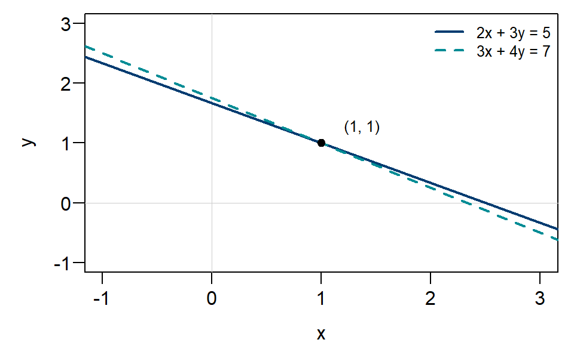

# 5 Exercise 5

Use natural logarithms, written $\ln$.

a. Evaluate $\ln(1)$, $\ln(e)$, and $\ln(e^2)$.

b. Output increases from 100 to 105. Calculate its exact percentage growth rate.

c. For the same change, calculate $100[\ln(105)-\ln(100)]$. Round to two decimal places and compare with your answer to part (b).

**Answer:**

a. $\ln(1)=0$, $\ln(e)=1$, and $\ln(e^2)=2$: a natural logarithm gives the power to which $e$ is raised.

b. The exact percentage growth rate is

$$g=\frac{105-100}{100}\times100=5\%.$$

c. The log-change approximation is

$$100[\ln(105)-\ln(100)]=100\ln(1.05)\approx4.88\%.$$

This is close to, but not exactly, 5%. Log changes approximate percentage changes for small proportional movements. Both output values are positive, so the logarithms are defined.

# 6 Exercise 6

Find the derivative of each function. For part (d), take $x>0$.

a. $f(x)=8x$.

b. $f(x)=5x+x^3$.

c. $f(x)=x^4+x+10$.

d. $f(x)=\ln x$.

**Answer:**

For a power, use $\frac{d}{dx}x^n=nx^{n-1}$. The derivative of a constant is zero.

a. $f'(x)=8$.

b. $f'(x)=5+3x^2$.

c. $f'(x)=4x^3+1$.

d. $f'(x)=1/x$, for $x>0$.

These are slope calculations. No economic model or proof of the differentiation rules is required.